# TidyTueday - Collegiate Sports

Hans Elliott

2022-03-29

### Setup

Loading packages

```r
## LOAD LIBRARIES
if (!require("pacman")) install.packages("pacman")
##
pacman::p_load(dplyr, magrittr,              #for cleaning/sorting/filtering
               tidytuesdayR,                 #for accessing the data
               ggplot2, ggthemes)            #for plotting
```

### Figure 1: Gender Difference in Collegiate Sports Expenditure

**(Diverging Lollipop Chart)**

Load in the data from [TidyTuesday repo](https://github.com/rfordatascience/tidytuesday/blob/master/data/2022/2022-03-29/readme.md).

```r
#load in (most recent) TidyTuesday data using tidytuesdayR package
raw = tidytuesdayR::tt_load(2022, week = 13)
#sports data
sports = raw$sports
```

This week, the TidyTuesday data is related to **collegiate sports budgets.**  
It includes information like budget, revenue, and number of athletes per sport for over 2,000 higher ed institutions.

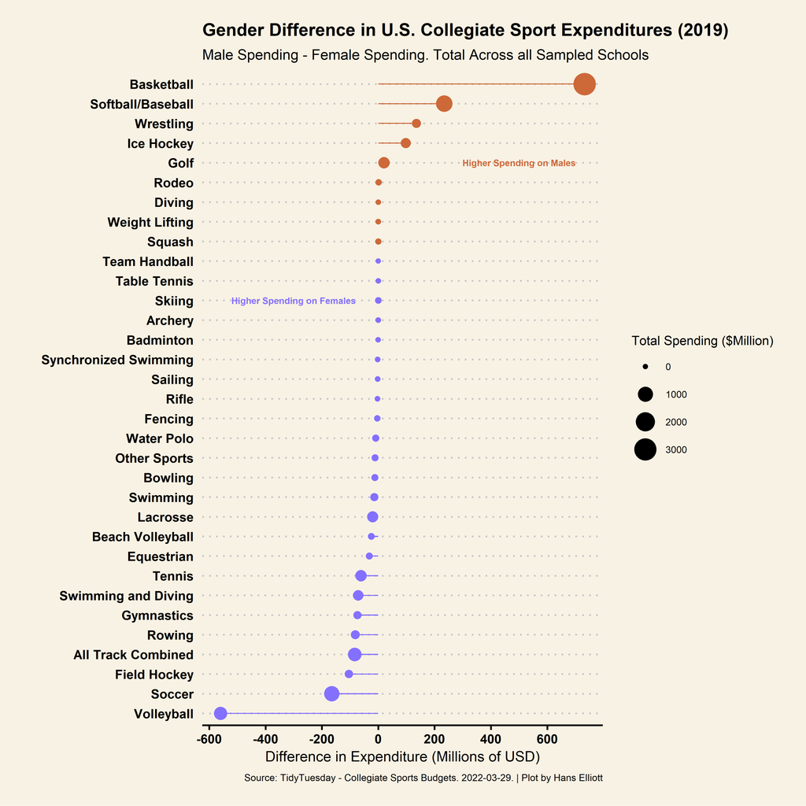

```r
## Figure 1
fig1 = sports %>%
  #filter out unwanted sports
  filter(sports != "Track and Field, Indoor" &        #(just including the All Track category)
         sports != "Track and Field, Outdoor" &
         sports != "Track and Field, X-Country" &
         sports != "Football" &                       #Football is a major outlier, and male only
         year == 2019) %>%                            #Most recent year
  #aggregate baseball/softball into one sport
  mutate(sports = ifelse(sports=="Baseball"|sports=="Softball",
                         "Softball/Baseball", sports)) %>%
  #group by sport and summarize
  group_by(sports) %>%
  summarise(rev_men = sum(rev_men, na.rm = T),
            rev_women = sum(rev_women, na.rm = T),
            exp_men = sum(exp_men, na.rm = T),
            exp_women = sum(exp_women, na.rm = T),
            tot_exp = (exp_men + exp_women)/1e6,    #(scale by 1 million $)
            diff_rev = (rev_men - rev_women)/1e6,
            diff_exp = (exp_men - exp_women)/1e6
            ) %>%
    #reorder sport categories by expenditure difference (descending)
  mutate(sports = reorder(sports, diff_exp),
    #add variables for convenience in mapping aesthetics
         exp_sign = ifelse(diff_exp > 0, 1, 0),
         rev_sign = ifelse(diff_rev > 0, 1, 0),
          ) %>%
    #PLOT:
  ggplot() +
    #points
    geom_point(aes(x = sports, y = diff_exp,
                   color = as.factor(exp_sign), size = tot_exp
                   )) +
    #geom_bar with tiny width to create a line from point to zero
    geom_bar(aes(x = sports, y = diff_exp, fill = as.factor(exp_sign)),
             stat = 'identity', width = 0.05) +
    #increase number of axis ticks
    scale_y_continuous(breaks = seq(-800, 800, by = 200)) +
    #labels
    labs(title = "Gender Difference in U.S. Collegiate Sport Expenditures (2019)",
         subtitle = "Male Spending - Female Spending. Total Across all Sampled Schools",
         x = "", y = "Difference in Expenditure (Millions of USD)",
         fill = "Higher Spending on", size = "Total Spending ($Million)",
         caption = "Source: TidyTuesday - Collegiate Sports Budgets. 2022-03-29. | Plot by Hans Elliott"
         ) +
    #legend
    guides(color = "none", fill = "none") +   #remove color/fill legend
    #update labels & colors
    scale_fill_manual(labels = c("Females", "Males"),
                      values = c("lightslateblue", "sienna3")) +
    #match color values to fill values
    scale_color_manual(values = c("lightslateblue", "sienna3")) +
    #annotation layers to reduce need for legends
    annotate("text", x = "Golf", y = 500,
             label = "Higher Spending on Males", color = "sienna3",
             fontface = 2, size = 2, family = "sans"
             ) +
    annotate("text", x = "Skiing", y = -300,
             label = "Higher Spending on Females", color = "lightslateblue",
             fontface = 2, size = 2, family = "sans"
              ) +
    #editing theme
    ggthemes::theme_wsj() +
        theme(legend.position = "right",
              legend.direction = "vertical",
              plot.title = element_text(size = "11", family = "sans"),
              plot.subtitle = element_text(size = "9", family = "sans"),
              axis.title = element_text(size = "9", family = "sans"),
              axis.text = element_text(size = "8", family = "sans"),
              legend.title = element_text(size = "8", family = "sans"),
              legend.text = element_text(size = "6"),
              plot.caption = element_text(size = "6", family = "sans"),
              panel.grid.major = element_line(color = "gray78")
              ) +
    coord_flip()

print(fig1)
```

This plot shows the gender gaps in collegiate sport expenditures for 2019, broken down by sport. The data is aggregated from over 2,000 higher ed institutions. It makes clear which sports have larger budgets for female teams, and which have larger budgets for male teams. It also shows the relative size of the overall spending on each sport.  
I was surprised to see that, for many sports, the female teams receive higher expenditures (in aggregate). This goes against my prior assumptions, based on recent events and news.  
Another interesting point is that for the largest male-favoring gaps the overall expenditure on the sport is quite large relative to the largest female-favoring gaps (for example, see basketball and softball/baseball compared to volleyball and soccer).  
This seems consistent with reports that spending on male sports is higher than female sports.

### Figure 2: School Size & Sport Budget

**(Binned Scatterplots)**

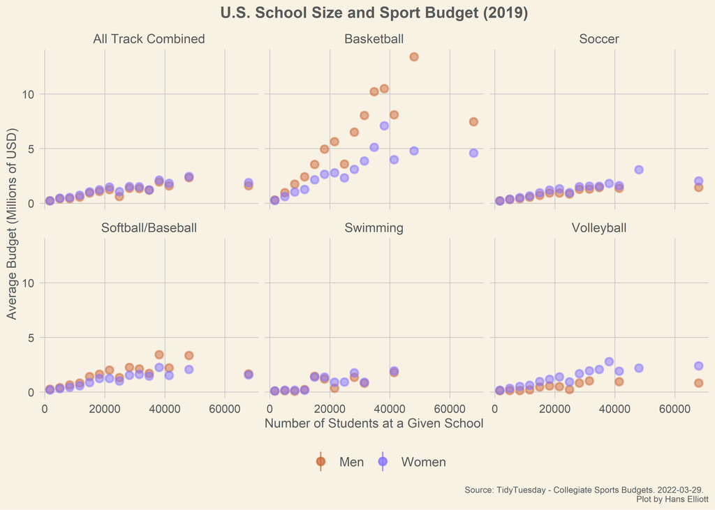

```r
## Figure 2
fig_2 = sports %>%
  #filter to specific sports. again, use most recent year
  filter((sports == "Basketball" |
         sports == "Softball" |
         sports == "Baseball" |
         sports == "Swimming" |
         sports == "Volleyball" |
         sports == "Soccer" |
         sports == "All Track Combined") &
         year == 2019
         ) %>%
  #aggregate baseball/softball into one sport
  mutate(sports = ifelse(sports=="Baseball"|sports=="Softball",
                         "Softball/Baseball", sports)) %>%
  #PLOT:
  ggplot() +
    #Binned scatter plots
    stat_summary_bin(aes(x = ef_total_count, y = exp_men/1e6, color = "Men"),
                     fun = 'mean', bins = 20, alpha = 0.5) +
    stat_summary_bin(aes(x = ef_total_count, y = exp_women/1e6, color = "Women"),
                     fun = 'mean', bins = 20, alpha = 0.5) +
    facet_wrap(~sports) +
    labs(title = "U.S. School Size and Sport Budget (2019)",
         x = "Number of Students at a Given School",
         y = "Average Budget (Millions of USD)",
         color = "",
                  caption = "Source: TidyTuesday - Collegiate Sports Budgets. 2022-03-29.
         Plot by Hans Elliott") +
    scale_color_manual(values = c("sienna3", "lightslateblue")) +
    #editing theme
    ggthemes::theme_excel_new() +
        theme(panel.background = element_rect(fill = "#F8F2E4"),
              plot.background = element_rect(fill = "#F8F2E4"),
              legend.background = element_rect(fill = "#F8F2E4"),
              legend.key = element_rect(fill = "#F8F2E4"),
              legend.position = "bottom",
              legend.direction = "horizontal",
              plot.title = element_text(size = "11", family = "sans",
                                        face = "bold"),
              plot.subtitle = element_text(size = "9", family = "sans"),
              axis.title = element_text(size = "9", family = "sans"),
              axis.text = element_text(size = "8", family = "sans"),
              legend.title = element_text(size = "9", family = "sans"),
              legend.text = element_text(size = "9"),
              plot.caption = element_text(size = "6", family = "sans"),
              panel.grid.major = element_line(color = "gray78")
              )

print(fig_2)
```

In these binned scatterplots we can see the average budget (across all schools in the data) for different sports, conditional on the number of students attending a given school.  
For most of the sports shown above, there does appear to be a linear relationship between the size of the school and the size of spending - this is no surprise, as these larger schools likely compete in higher divisions, have more resources, etc.  
These plots also break out the average budget by binary gender. For many of the sports, spending is fairly equal between genders at each bin of student quantity. Basketball is an interesting exception. The size of the budget increases almost exponentially with school size for males, but this relationship is weaker for females.

[Hans Elliott](https://hans-elliott99.github.io/)

*hanselliott61@gmail.com*